# hw_05: Factor and figure management

SL_Ivy

## Goal

The goal of this homework is to get expand the thinking about data portability, collaboration, and dissemination. In this assignment, we will also learn to import and export the datasets and practice effective plotting principles.

## Setup the working environment for the data analysis

Make sure `gapminder`, `tidyverse`, and `DT` packages are installed. Load them with the following code:

```r
library(gapminder)
library(tidyverse)
library(DT)
library (here)
library(grid)
library(gridExtra)
```

## Exercise 1: Explain the value of the here::here package

The `here` package provide a simpler way to create and find the files. The `here()` function in this package works in a platform-independent way, which means that the same code works on both **Mac OS** and **Windows** operating systems without needing any modification. It uses “, “ to separate each subdirectory instead of “/” in Mac OS or “ ” in Windows. For example, it can build a path to something in a subdirectory and use it by the code like: `here("User", "Ivy", “STAT 545”, "test.txt")`. This is very useful for document/file sharing between different operating system. Besides, it is particularly useful when we work with the R Markdown. Because R Markdown documents always knit assuming the location of the .Rmd file is the working directory. When the R Markdown file is saved in a sub-directory, it wouldn’t be able to access the file by using a relative path from the root directory. We have to specific everything from top-to-bottom of the pathway, which cannot avoid using either “/” or “ ”. All of those confusions can be avoid by using `here ()` function, like `here (“subfolder”, “test.txt”)`, which uses a reasonable heuristics to find the project’s files. Generally, `here` package provides a simple and robust way for people to open/create files, share code across different operating platforms.

## Exercise 2: Factor management

Dataset: `gapminder` Variable: `continent`

Task 1: Drop factor Before we drop any factor, let’s see all the possible factors in `continent`:

```r
levels(gapminder$continent)
```

```
## [1] "Africa"   "Americas" "Asia"     "Europe"   "Oceania"
```

- Filter the Gapminder data to remove observations associated with the continent of **Asia**:

```r
without_Asia <- filter(gapminder, continent != 'Asia') %>%
  droplevels()
```

- Provide concrete information on the data before and after removing **Asia**: The `str()` function can be use to see the overall changes for each variable after the removal.

```r
str(without_Asia) #new dataset#
```

```
## Classes 'tbl_df', 'tbl' and 'data.frame':    1308 obs. of  6 variables:
##  $ country  : Factor w/ 109 levels "Albania","Algeria",..: 1 1 1 1 1 1 1 1 1 1 ...
##  $ continent: Factor w/ 4 levels "Africa","Americas",..: 3 3 3 3 3 3 3 3 3 3 ...
##  $ year     : int  1952 1957 1962 1967 1972 1977 1982 1987 1992 1997 ...
##  $ lifeExp  : num  55.2 59.3 64.8 66.2 67.7 ...
##  $ pop      : int  1282697 1476505 1728137 1984060 2263554 2509048 2780097 3075321 3326498 3428038 ...
##  $ gdpPercap: num  1601 1942 2313 2760 3313 ...
```

```r
str(gapminder)#original dataset
```

```
## Classes 'tbl_df', 'tbl' and 'data.frame':    1704 obs. of  6 variables:
##  $ country  : Factor w/ 142 levels "Afghanistan",..: 1 1 1 1 1 1 1 1 1 1 ...
##  $ continent: Factor w/ 5 levels "Africa","Americas",..: 3 3 3 3 3 3 3 3 3 3 ...
##  $ year     : int  1952 1957 1962 1967 1972 1977 1982 1987 1992 1997 ...
##  $ lifeExp  : num  28.8 30.3 32 34 36.1 ...
##  $ pop      : int  8425333 9240934 10267083 11537966 13079460 14880372 12881816 13867957 16317921 22227415 ...
##  $ gdpPercap: num  779 821 853 836 740 ...
```

It can be found that 396 observations that associated with Asia were dropped. There is 5 levels of the continent in the original dataset, `gapminder`, and 4 levels of the continent in the new dataset, `without_Asia`. Besides, the levels of country variable was also changed from 142 to 109. The total observations was dropped from 1704 to 1308.

If the information above seems little bit overwhelming, there is an alternative way to figure out the changes one by one via the `nlevels()` function:

To check the level changes of the country:

```r
nlevels(gapminder$country)
```

```
## [1] 142
```

```r
nlevels(without_Asia$country)
```

```
## [1] 109
```

Same code with the continent:

```r
nlevels(gapminder$continent) #number of levels of continent in the origianl dataset
```

```
## [1] 5
```

```r
levels(gapminder$continent)  #what are the possile values of the variable
```

```
## [1] "Africa"   "Americas" "Asia"     "Europe"   "Oceania"
```

```r
nlevels(without_Asia$continent) #number of levels of continent in the new dataset
```

```
## [1] 4
```

```r
levels(without_Asia$continent)#what are the possible values of the variable
```

```
## [1] "Africa"   "Americas" "Europe"   "Oceania"
```

To address the changes of the observations:

```r
count(gapminder)
```

```
## # A tibble: 1 x 1
##       n
##   <int>
## 1  1704
```

```r
count(without_Asia)
```

```
## # A tibble: 1 x 1
##       n
##   <int>
## 1  1308
```

- Address the number of rows of the affected factors.

```r
nrow(gapminder)
```

```
## [1] 1704
```

```r
nrow(without_Asia)
```

```
## [1] 1308
```

Task 2: Reorder the levels of continent

To reorder the contient by the maximum of population in an ascending order.

```r
reo_continent<-fct_reorder(gapminder$continent, gapminder$pop, max)
levels(reo_continent)
```

```
## [1] "Oceania"  "Europe"   "Africa"   "Americas" "Asia"
```

It can be found that Asia has the largest population size and Oceania has the smallest population size.

We can compare the before and after reordered data set by ploting them here:

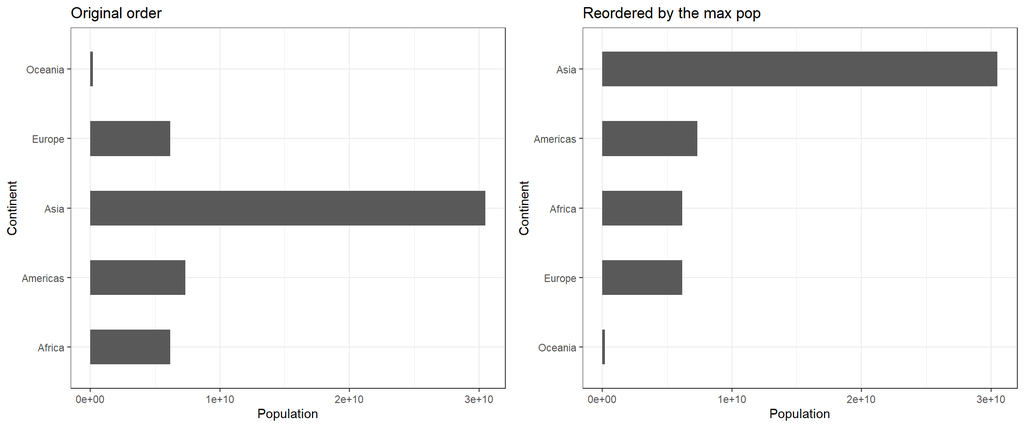

```r
F1 <-gapminder %>%
  ggplot() +
  geom_col(aes(continent, pop), width = 0.5) +
  coord_flip()+   # flip x and y
  theme_bw() +
  ylab("Population") + xlab("Continent")+ggtitle('Original order')


F2 <- gapminder %>%
  ggplot() +
  geom_col(aes(reo_continent, pop), width = 0.5) +
  coord_flip()+   # flip x and y
  theme_bw() +
  ylab("Population") + xlab("Continent")+ggtitle('Reordered by the max pop')
grid.arrange(F1, F2, nrow=1)
```

## Exercise 3: File input/output

Step 1: Create something new For example, we are going to further explore the GDP per Capital in Americas, we will need to filter the data and save them into a new file.

```r
Americas_data <- gapminder %>%
  filter (continent == "Americas") %>%
  select (continent, country, year, gdpPercap)
```

Step 2: Create a new file to store this data:

```r
write_csv(Americas_data, here::here('hw05','Americas_data.csv'))
```

Step 3: Reload it back

```r
reload_Am <-read_csv(here::here('hw05','Americas_data.csv'))
reload_Am
```

```
## # A tibble: 300 x 4
##    continent country    year gdpPercap
##    <chr>     <chr>     <dbl>     <dbl>
##  1 Americas  Argentina  1952     5911.
##  2 Americas  Argentina  1957     6857.
##  3 Americas  Argentina  1962     7133.
##  4 Americas  Argentina  1967     8053.
##  5 Americas  Argentina  1972     9443.
##  6 Americas  Argentina  1977    10079.
##  7 Americas  Argentina  1982     8998.
##  8 Americas  Argentina  1987     9140.
##  9 Americas  Argentina  1992     9308.
## 10 Americas  Argentina  1997    10967.
## # ... with 290 more rows
```

With the imported data, play around with factor levels and use factors to order your data with one of your factors (i.e. non-alphabetically). To check the levels for the factors including in this file

```r
str(reload_Am)
```

```
## Classes 'spec_tbl_df', 'tbl_df', 'tbl' and 'data.frame': 300 obs. of  4 variables:
##  $ continent: chr  "Americas" "Americas" "Americas" "Americas" ...
##  $ country  : chr  "Argentina" "Argentina" "Argentina" "Argentina" ...
##  $ year     : num  1952 1957 1962 1967 1972 ...
##  $ gdpPercap: num  5911 6857 7133 8053 9443 ...
##  - attr(*, "spec")=
##   .. cols(
##   ..   continent = col_character(),
##   ..   country = col_character(),
##   ..   year = col_double(),
##   ..   gdpPercap = col_double()
##   .. )
```

To reorder it by the max of GDP per Capital for each country:

```r
reo_Am<-fct_reorder(reload_Am$country, reload_Am$gdpPercap, max)
levels(reo_Am)
```

```
##  [1] "Haiti"               "Honduras"            "Bolivia"
##  [4] "Paraguay"            "Guatemala"           "Nicaragua"
##  [7] "El Salvador"         "Dominican Republic"  "Colombia"
## [10] "Peru"                "Ecuador"             "Jamaica"
## [13] "Cuba"                "Brazil"              "Costa Rica"
## [16] "Panama"              "Uruguay"             "Mexico"
## [19] "Argentina"           "Venezuela"           "Chile"
## [22] "Trinidad and Tobago" "Puerto Rico"         "Canada"
## [25] "United States"
```

To visualize the trend:

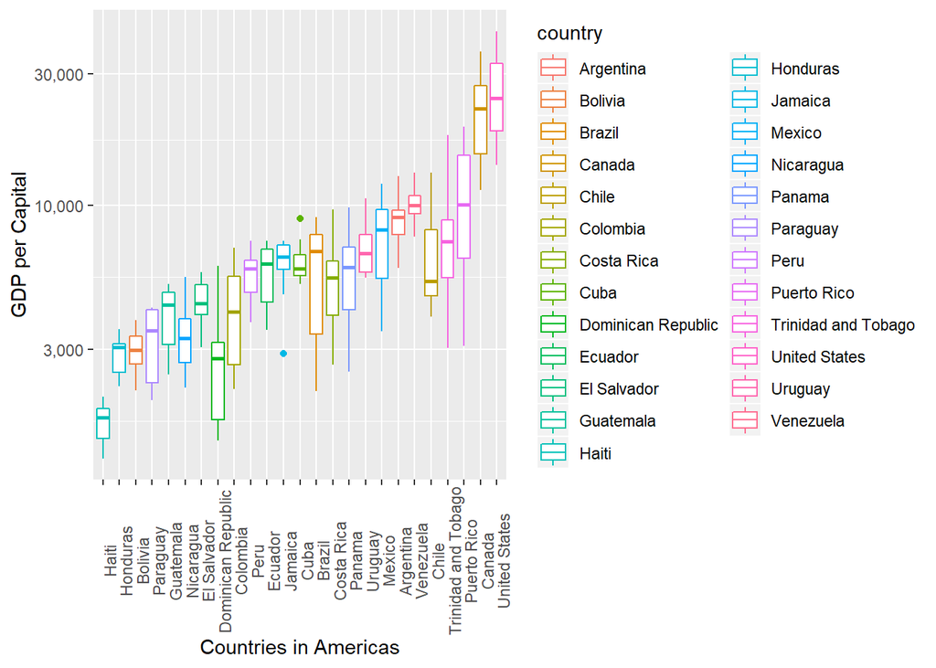

```r
reload_Am %>% ggplot(aes(reo_Am, gdpPercap, colour = country))+
      geom_boxplot()+
      scale_y_log10(labels=scales::comma) +
      theme(axis.text.x = element_text(angle = 90))+ylab("GDP per Capital") + xlab("Countries in Americas")
```

For the I/O method(s) you chose, comment on whether or not your newly created file survived the round trip of writing to file then reading back in.

Run the code to check if the exported and imported data are identical

```r
summary(Americas_data == reload_Am)
```

```
##  continent      country          year         gdpPercap
##  Mode:logical   Mode:logical   Mode:logical   Mode:logical
##  TRUE:300       TRUE:300       TRUE:300       TRUE:300
```

Based on the obeservation of the above session, it can be found that newly created file, *Amricas_data* was correctly export and stored in the designed file.Then it was able to be properly imported back. By using the `write_csv()/read_csv()` and `here::here(), the file can be easily addressed.

## Exercise 4: Visualization design

Go back through your previous assignments and class participation activities and find figures you created prior to the last week of the course. Recreate at least one figure in light of something you learned in the recent class meetings about visualization design and color.

I choose a plot that I did for my assigment 3, task option 2, which is shown in below:

```r
GDP_summary <- gapminder %>%
  select (continent, gdpPercap) %>%
  group_by(continent) %>%
  summarise(Max_GDP=max(gdpPercap), Min_GDP=min(gdpPercap))
knitr::kable(GDP_summary, format = 'html', align ='c')
```

| continent | Max_GDP | Min_GDP |
| --- | --- | --- |
| Africa | 21951.21 | 241.1659 |
| Americas | 42951.65 | 1201.6372 |
| Asia | 113523.13 | 331.0000 |
| Europe | 49357.19 | 973.5332 |
| Oceania | 34435.37 | 10039.5956 |

```r
old_figure <- ggplot(GDP_summary, aes(x=continent)) +
  geom_point(aes(y=Max_GDP, color="Max_GDP")) +
  geom_point(aes(y=Min_GDP, color="Min_GDP"))+
  scale_y_log10(labels = scales::comma_format())+
  ggtitle("Old")
```

I think it would be better to change the plot type and reorder it by the median of GDP per Capital, and add individual observations:

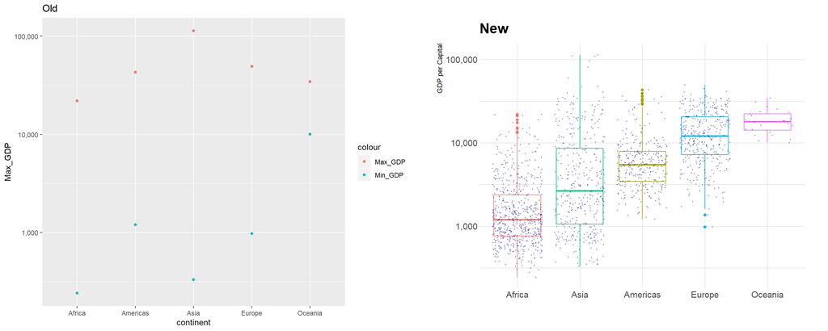

```r
library(hrbrthemes)
library(viridis)
new_order <- fct_reorder(gapminder$continent, gapminder$gdpPercap, median)
new_figure <- ggplot(gapminder, aes(new_order, gdpPercap, group = continent, colour = continent)) +
  geom_boxplot() +
  scale_y_log10(labels = scales::comma_format()) +
  ggtitle("New")+
  scale_fill_viridis(discrete = TRUE, alpha=0.6) +
    geom_jitter(color="dark blue", size=0.4, alpha=0.3) +
    theme_ipsum() +
    theme(
      legend.position="none")+xlab("")+ylab("GDP per Capital")
grid.arrange(old_figure, new_figure, nrow=1)
```

## Exercise 5: Writing figures to file

Use ggsave() to explicitly save a plot to file. Include the exported plot as part of your repository and assignment.

```r
ggsave("new_figure.jpg",
       plot =new_figure, #specify the plot is important, see the explaintion below the code chunk
       width = 16, height =12, units = "cm")
```

Whithout speficication, `ggsave()` always save the last created plot. In this case, it won’t preduce any different result, but it’s a good practice to specify the exact plot for the future review (even the author can forget the details without proper reminder).

And then to check if the plot was properly saved by reloading it here:

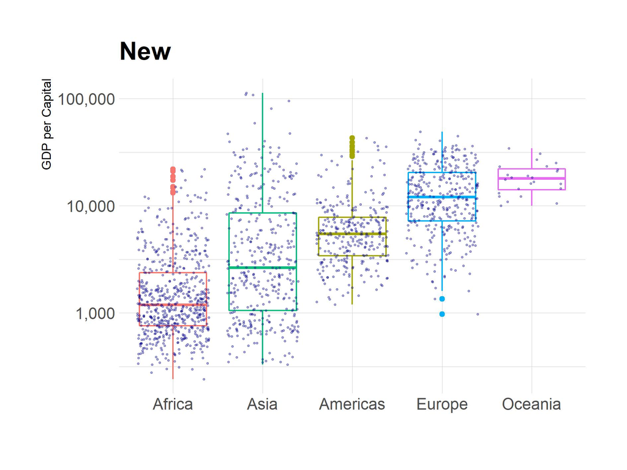

Reload the new figure